# Global CO2 emissions and GDP per Capita.

2020 AI Data Report.

August 25, 2025

## Introduction

This report analyzes the relationship between carbon dioxide (CO2) emissions per capita and GDP per capita across countries worldwide in 2020. Understanding this relationship is crucial for environmental policy and sustainable development discussions.

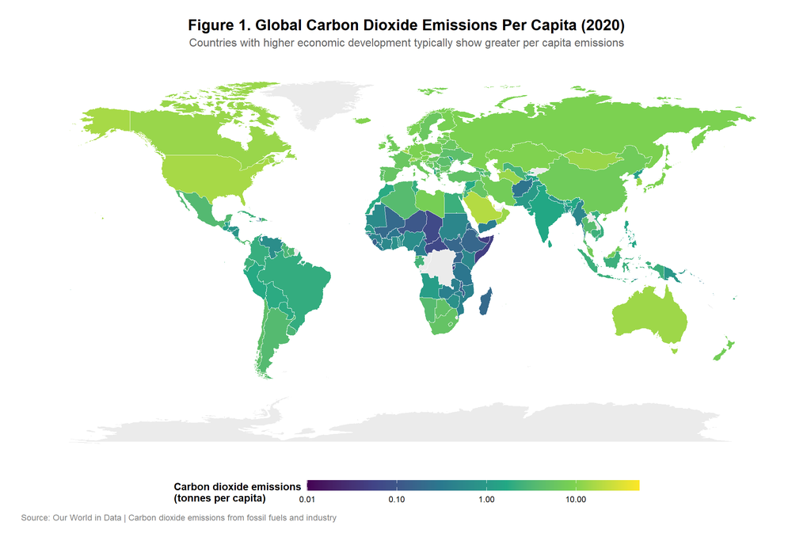

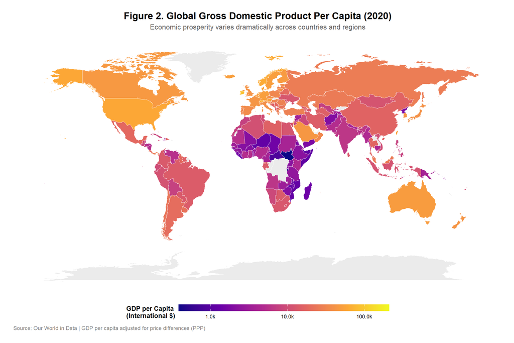

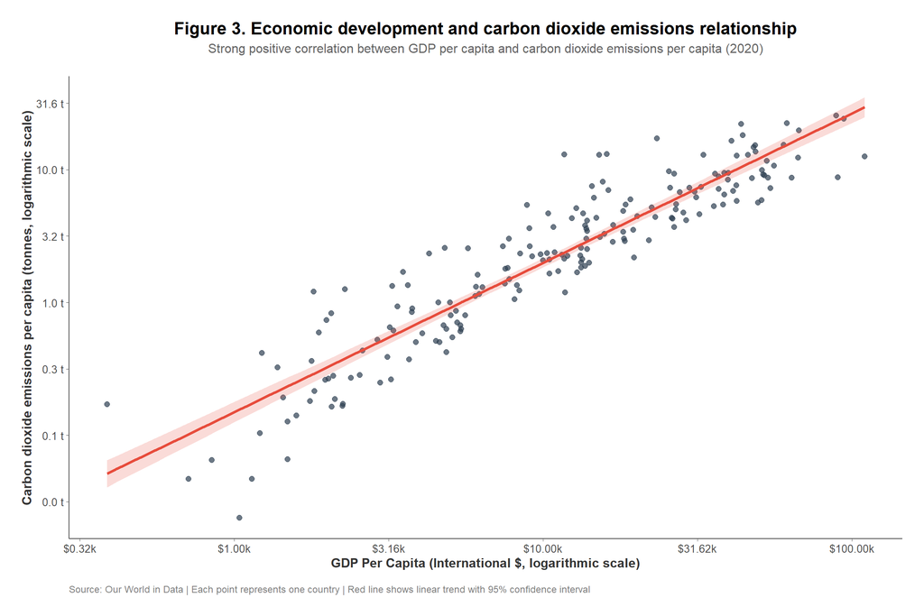

### Statistical Analysis

Statistical Summary of Relationship

| Metric | Value |
| --- | --- |
| Pearson Correlation (log-log) | 0.924 |
| R-squared | 0.854 |
| P-value | 1.07e-81 |
| Number of Countries | 193 |

## Interpretation and Conclusions

The analysis reveals several important patterns in the relationship between economic development and carbon emissions:

**1. Strong Positive Correlation:** There is a strong positive correlation (r = 0.924) between GDP per capita and CO2 emissions per capita when both variables are log-transformed. This suggests that as countries become wealthier, their per capita carbon emissions tend to increase.

**2. Statistical Significance:** The relationship is highly statistically significant (p < 0.001), indicating that this pattern is not due to random chance. The model explains approximately 85.4% of the variance in CO2 emissions.

**3. Regional Patterns:** - **High-income, high-emission countries** (e.g., Gulf states, North America, Australia) show both high GDP and high CO2 emissions - **Developing countries** generally cluster in the lower-left of the plot with lower GDP and lower emissions - **Some outliers exist** where countries have relatively high emissions despite moderate GDP levels

**4. Policy Implications:** - The strong relationship suggests that economic growth has historically been coupled with increased carbon emissions - This highlights the challenge of decoupling economic development from environmental impact - Countries with high GDP but relatively lower emissions may provide models for sustainable development

### Limitations

- This analysis represents a snapshot of 2020 data and doesn’t capture trends over time
- The relationship may be influenced by factors not considered here, such as energy mix, industrial structure, and climate
- Some countries may have incomplete or uncertain data

### Future Research Directions

- Examine trends over time to see if decoupling is occurring
- Include additional variables such as renewable energy adoption and energy efficiency
- Analyze sub-national variations within large countries

## Reflection on Interacting with AI Tools

Engaging with Cursor was a surprisingly smooth and empowering experience. The intuitive interface made it easy to translate my ideas into action. I simply described the visualization I had in mind and the statistical measures I wanted, and within minutes, a complete report was generated. It included .html and .Rmd files with code structured exactly as I would write in RStudio—except it would’ve taken me hours to do manually.

### What was difficult?

The initial setup, subscribing to Cursor and configuring the path, was a bit tricky. But with careful attention, I managed to navigate through it successfully.

### What was surprising?

The speed and accuracy were astonishing. With just a few notes, the entire workflow came to life. I used to spend hours writing and debugging code, often switching between Copilot and ChatGPT. But Cursor streamlined the process, making it feel effortless. It revealed how AI can make learning to code more accessible and less intimidating.

### What did I learn?

AI agents hold immense potential for automating coding tasks and generating reports—especially when time is tight and deadlines are looming. They’re not just tools; they’re accelerators of productivity and creativity.